# Final Paper

STOR 320.01 Group 5

November 21, 2022

# INTRODUCTION

The National Basketball Association (NBA) is one of the most popular sports leagues across the globe, and most definitely the biggest basketball league at that. Today’s game of basketball continues to evolve every year in terms of gameplay, strategy, and the characteristics of the players themselves. In this project, two questions, in particular, will help evaluate this evolution.

Point differential is arguably the greatest statistic to determine how well a certain lineup performs. After all, the goal of basketball is to outscore your opponent, therefore it is logical to assume that exhibiting a positive point differential plays a pivotal role in determining whether a team wins or loses. With that being said, which variables can accurately predict a lineup’s point differential? To answer this, we will create the best model with the techniques that we have learned to accurately predict a lineup’s point differential. With a reliable model, NBA statisticians, coaches, and general managers would be able to understand what changes are needed within their teams to improve their point differentials and therefore win more games, something that all basketball fans can benefit from.

In addition to point differential, the newly found prevalence of international players in today’s version of the NBA caught our eyes as a group. We wanted to know how have international players become more utilized in recent NBA history. More specifically, are they more present in later-used lineups? Do the most used lineups have international players? The significance of these questions can best be seen in the 21st century, as international players have not only increased their population in the NBA but have also played major roles within their organizations. For example, the past four Most Valuable Player awards have gone to international-born players, forcing scouts to broaden their horizons beyond just the NCAA, but overseas as well. By answering these questions, one can better understand the impact of international players on the NBA, and get an idea of why scouts are as intrigued as they are by top international prospects, such as 19-year-old, Victor Wembanyama, who is the biggest draft prospect since Lebron James himself.

With these two questions answered, we would be able to have a stronger understanding of how a team can improve their point differentials (which could lead to more wins, hence better fan approval) and the level of importance that international-born players have in today’s NBA.

# DATA

Our dataset was scraped from the popular basketball data-sourcing website Cleaning The Glass. This website was created by Ben Falk, a notable statistician and data scientist who previously worked with several NBA teams. The data itself was collected by sportradar, which is renowned for its large databases of major sports. For this project, we used the data present on lineups, which can be found here. This lineup data is available for every year of NBA basketball since 2004 and includes several divisions of basketball statistics including efficiency differential (points scored per offensive possession - points allowed per defensive possession), shooting efficiency, shooting locations, halfcourt offense, transition/fastbreaks, and more – for both offense and defense. As for the observations in our dataset, each row represents a single lineup that played at least 100 possessions. In total, there are 6,284 lineups since 2004 that met this requirement. Cleaning The Glass includes the names of all 5 players in the lineup, but doesn’t include any biographical information about them (which we need for our question of international representation). To remedy this, we scraped the players’ biographical information from NBA.com and ran a match function to combine the two datasets. Once we accomplished this, our dataset looked as follows:

| PG | Poss | Diff | OFFENSE..Pts.Poss | OFFENSE..eFG. |
| --- | --- | --- | --- | --- |
| Mike Bibby | 2097 | 13.9 | 117.2 | 56.8 |
| Jason Kidd | 1923 | 7.9 | 101.2 | 47.7 |
| Andre Miller | 1901 | 8.2 | 106.5 | 49.6 |
| Steve Francis | 1792 | 10.1 | 103.9 | 50.7 |
| Baron Davis | 1310 | -0.9 | 97.3 | 44.6 |
| Chauncey Billups | 1289 | 9.5 | 101.6 | 45.2 |

| PG | PG.Height | PG.Age | PG.Experience | PG.GP | PG.Draft.Year | PG.Draft.Pick | PG.Nationality |
| --- | --- | --- | --- | --- | --- | --- | --- |
| Mike Bibby | 74 | 25 | 5 | 82 | 1998 | 2 | United States |
| Jason Kidd | 76 | 30 | 9 | 67 | 1994 | 2 | United States |
| Andre Miller | 75 | 27 | 4 | 82 | 1999 | 8 | United States |
| Steve Francis | 75 | 27 | 4 | 79 | 1999 | 2 | United States |
| Baron Davis | 75 | 24 | 4 | 67 | 1999 | 3 | United States |
| Chauncey Billups | 75 | 27 | 6 | 78 | 1997 | 3 | United States |

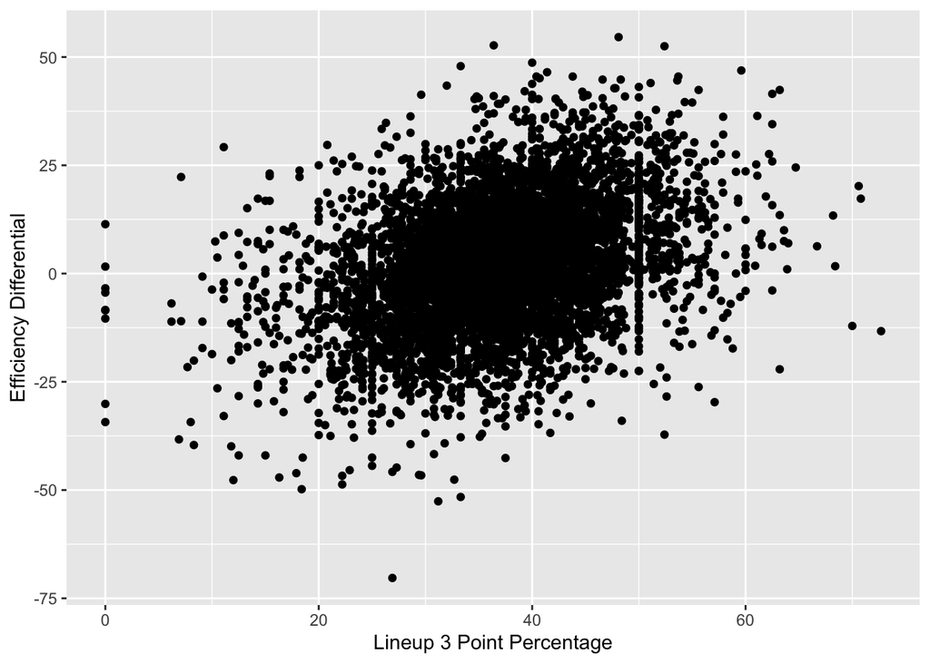

For our question of international representation, we used the player’s nationality, the number of lineups with international players played, the years of said lineups, and the number of played possessions of lineups with international players. For players who have two countries listed under nationality, the first country is their birth country and the second is their assumed nationality if they grew up in a different location. The impact of these specific values will be further discussed in the analysis of international players. For our question of predictors for a lineup’s point/efficiency differential, it was much more difficult to establish a limited number of variables of interest. We were looking to work backwards and eliminate many of the variables when creating a model. However, we were aware some variables were pointless to include, even in a full model. So, before building this model, we eliminated several variables such as player name, team, draft year, and nationality. We kept all other variables. Some of the most important efficiency statistics included effective field goal percentage (a general metric for shooting percentage), points scored per possession, percentage of plays a turnover occurred, and free throw percentage, along with shooting percentages for every area of the court. GGplot of one variable vs. point differential

# RESULTS

In the NBA statistics community, efficiency differential is commonly used to determine the prevalence of a lineup. As opposed to simple point differential (subtracting number of points allowed from number of points scored), efficiency differential subtracts the number of points allowed per 100 possessions from the points scored per 100 possessions. Our goal was to create a model that would help predict this value from the lineup data we collected. To begin, we created a full model using all variables except those mentioned previously in the paper (name, team, etc. – variables bearing no supposed impact on predictions).

Barely any coefficients in this model were significant at the 0.05 alpha level, which meant a full model was nowhere close to being an acceptable predictor for efficiency differential. In addition, when we look at the residual vs. fitted plot and normality plot for this full model, severe concerns are present. Both equal variance and normality can absolutely NOT be assumed.

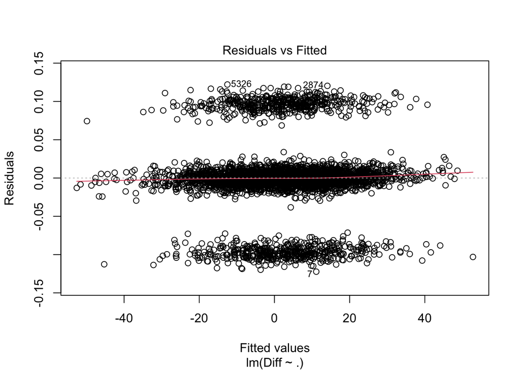

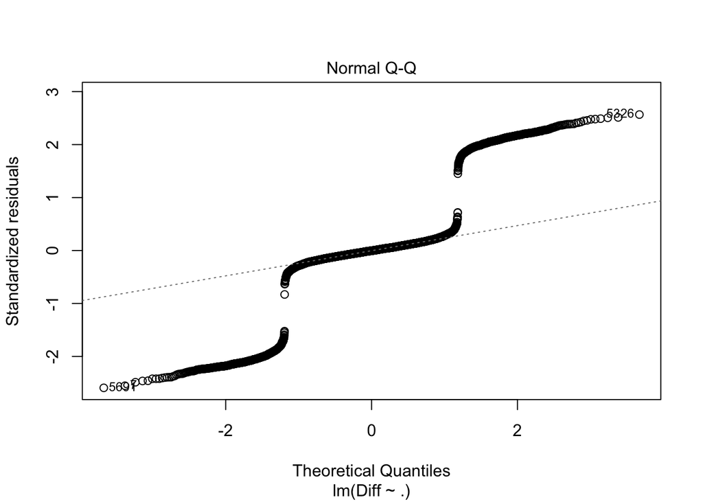

```
##
## Call:
## lm(formula = Diff ~ ., data = fulldata2)
##
## Residuals:
##       Min        1Q    Median        3Q       Max
## -0.122432 -0.007768 -0.000152  0.007440  0.121597
##
## Coefficients:
##                                            Estimate Std. Error   t value
## (Intercept)                               3.370e-01  2.372e+00     0.142
## PG.Age                                    5.668e-04  6.282e-04     0.902
## PG.Experience                            -9.214e-04  6.728e-04    -1.369
## PG.GP                                    -5.876e-05  6.500e-05    -0.904
## PG.Draft.Pick                             1.638e-04  7.374e-05     2.221
## SG.Age                                   -6.009e-04  5.493e-04    -1.094
## SG.Experience                             7.869e-04  5.759e-04     1.367
## SG.GP                                    -5.450e-06  6.595e-05    -0.083
## SG.Draft.Pick                            -9.933e-06  7.660e-05    -0.130
## SF.Age                                   -8.492e-04  5.152e-04    -1.649
## SF.Experience                             6.071e-04  5.364e-04     1.132
## SF.GP                                    -7.505e-05  6.913e-05    -1.086
## SF.Draft.Pick                            -6.434e-05  7.892e-05    -0.815
## PF.Age                                   -2.160e-04  4.925e-04    -0.438
## PF.Experience                             4.133e-04  5.171e-04     0.799
## PF.GP                                     8.683e-05  7.210e-05     1.204
## PF.Draft.Pick                             2.512e-05  8.029e-05     0.313
## C.Age                                    -2.719e-04  5.143e-04    -0.529
## C.Experience                              3.645e-04  5.523e-04     0.660
## C.GP                                     -3.585e-05  6.283e-05    -0.571
## Average.Height                            4.111e-04  1.043e-03     0.394
## C.Draft.Pick                             -8.270e-05  7.381e-05    -1.120
## Poss                                      4.937e-06  2.947e-06     1.675
## Diff.Rank                                 7.765e-05  1.222e-04     0.635
## OFFENSE..Pts.Poss.Rank                   -1.182e-04  1.324e-04    -0.893
## OFFENSE..Pts.Poss                         1.000e+00  4.481e-04  2232.538
## OFFENSE..eFG..Rank                        4.199e-05  1.291e-04     0.325
## OFFENSE..eFG.                            -1.253e-03  9.955e-04    -1.259
## OFFENSE..TOV..Rank                       -9.414e-06  1.002e-04    -0.094
## OFFENSE..TOV.                             1.416e-04  1.016e-03     0.139
```

[output cut: 211 more lines]

```
## DEFENSE.HALFCOURT....of.Plays.Rank        0.99361
## DEFENSE.HALFCOURT....of.Plays             0.75910
## DEFENSE.PUTBACKS..Pts.Miss.Rank           0.56537
## DEFENSE.PUTBACKS..Pts.Miss                0.76609
## DEFENSE.PUTBACKS..Plays.Miss.Rank         0.74195
## DEFENSE.PUTBACKS..Plays.Miss              0.92021
## DEFENSE.PUTBACKS..Pts.Play.Rank           0.80273
## DEFENSE.PUTBACKS..Pts.Play                0.47427
## ---
## Signif. codes:  0 '***' 0.001 '**' 0.01 '*' 0.05 '.' 0.1 ' ' 1
##
## Residual standard error: 0.04846 on 4023 degrees of freedom
##   (2137 observations deleted due to missingness)
## Multiple R-squared:      1,  Adjusted R-squared:      1
## F-statistic: 2.784e+06 on 123 and 4023 DF,  p-value: < 2.2e-16
```

```
##                                   PG.Age
##                                12.195595
##                            PG.Experience
##                                12.072181
##                                    PG.GP
##                                 1.177870
##                            PG.Draft.Pick
##                                 1.237211
##                                   SG.Age
##                                 8.335923
##                            SG.Experience
##                                 8.364428
##                                    SG.GP
##                                 1.143856
##                            SG.Draft.Pick
##                                 1.188519
##                                   SF.Age
##                                 7.520383
##                            SF.Experience
##                                 7.478427
##                                    SF.GP
##                                 1.137829
##                            SF.Draft.Pick
##                                 1.148860
##                                   PF.Age
##                                 7.024807
##                            PF.Experience
##                                 7.200470
##                                    PF.GP
##                                 1.203704
##                            PF.Draft.Pick
##                                 1.220454
##                                    C.Age
##                                 7.786302
##                             C.Experience
##                                 7.863806
##                                     C.GP
##                                 1.160565
##                           Average.Height
##                                 1.266752
```

[output cut: 191 more lines]

```
##                                15.102766
##            DEFENSE.HALFCOURT....of.Plays
##                                16.175180
##          DEFENSE.PUTBACKS..Pts.Miss.Rank
##                                18.150940
##               DEFENSE.PUTBACKS..Pts.Miss
##                                29.025647
##        DEFENSE.PUTBACKS..Plays.Miss.Rank
##                                20.773794
##             DEFENSE.PUTBACKS..Plays.Miss
##                                34.396078
##          DEFENSE.PUTBACKS..Pts.Play.Rank
##                                14.472853
##               DEFENSE.PUTBACKS..Pts.Play
##                                12.143939
```

```
##
## Call:
## lm(formula = Diff ~ PG.Experience + OFFENSE..Pts.Poss + OFFENSE..eFG. +
##     OFFENSE..TOV. + OFFENSE..ORB. + OFFENSE..FT.Rate + DEFENSE..eFG. +
##     DEFENSE..TOV. + DEFENSE..ORB. + DEFENSE..FT.Rate + OFFENSE..Rim.Frequency +
##     OFFENSE..All.Three.Frequency + OFFENSE..Short.Mid.FG. + OFFENSE..Corner.Three.FG. +
##     HALFCOURT..Pts.Play + HALFCOURT..OREB. + HALFCOURT....of.Plays +
##     PUTBACKS..Plays.Miss + DEFENSE..Corner.Three.Frequency +
##     DEFENSE..All.Three.Frequency + DEFENSE..Rim.FG. + DEFENSE..Short.Mid.FG. +
##     DEFENSE..Long.Mid.FG. + DEFENSE..Corner.Three.FG. + DEFENSE.HALFCOURT..Pts.Play +
##     DEFENSE.HALFCOURT....of.Plays + DEFENSE.PUTBACKS..Plays.Miss +
##     DEFENSE.PUTBACKS..Pts.Play, data = model1$model)
##
## Residuals:
##      Min       1Q   Median       3Q      Max
## -13.3771  -1.3598   0.0796   1.4279  12.1602
##
## Coefficients:
##                                   Estimate Std. Error t value Pr(>|t|)
## (Intercept)                     -23.205473   1.699520 -13.654  < 2e-16 ***
## PG.Experience                    -0.020945   0.009986  -2.098 0.036007 *
## OFFENSE..Pts.Poss                 1.065411   0.014484  73.558  < 2e-16 ***
## OFFENSE..eFG.                    -0.116771   0.025890  -4.510 6.65e-06 ***
## OFFENSE..TOV.                     0.116226   0.023330   4.982 6.56e-07 ***
## OFFENSE..ORB.                    -0.066204   0.019111  -3.464 0.000537 ***
## OFFENSE..FT.Rate                 -0.038438   0.007034  -5.464 4.92e-08 ***
## DEFENSE..eFG.                    -1.332340   0.021266 -62.652  < 2e-16 ***
## DEFENSE..TOV.                     1.067120   0.016884  63.204  < 2e-16 ***
## DEFENSE..ORB.                    -0.562053   0.010281 -54.668  < 2e-16 ***
## DEFENSE..FT.Rate                 -0.276092   0.006568 -42.034  < 2e-16 ***
## OFFENSE..Rim.Frequency            0.016451   0.006805   2.418 0.015665 *
## OFFENSE..All.Three.Frequency      0.011050   0.005713   1.934 0.053145 .
## OFFENSE..Short.Mid.FG.           -0.014352   0.004219  -3.402 0.000675 ***
## OFFENSE..Corner.Three.FG.        -0.007023   0.002255  -3.114 0.001860 **
## HALFCOURT..Pts.Play               0.019575   0.009351   2.093 0.036385 *
## HALFCOURT..OREB.                  0.021468   0.014514   1.479 0.139188
## HALFCOURT....of.Plays            -0.020245   0.012482  -1.622 0.104896
## PUTBACKS..Plays.Miss             -0.038091   0.011818  -3.223 0.001277 **
## DEFENSE..Corner.Three.Frequency  -0.048032   0.019803  -2.426 0.015329 *
## DEFENSE..All.Three.Frequency     -0.024591   0.008002  -3.073 0.002134 **
## DEFENSE..Rim.FG.                  0.014861   0.006585   2.257 0.024081 *
## DEFENSE..Short.Mid.FG.            0.014208   0.004701   3.023 0.002521 **
## DEFENSE..Long.Mid.FG.             0.009557   0.004806   1.989 0.046814 *
## DEFENSE..Corner.Three.FG.        -0.007275   0.002453  -2.965 0.003041 **
## DEFENSE.HALFCOURT..Pts.Play      -0.133104   0.010588 -12.571  < 2e-16 ***
## DEFENSE.HALFCOURT....of.Plays     0.030659   0.014916   2.055 0.039905 *
## DEFENSE.PUTBACKS..Plays.Miss     -0.052733   0.012208  -4.320 1.60e-05 ***
## DEFENSE.PUTBACKS..Pts.Play       -0.012251   0.001363  -8.991  < 2e-16 ***
## ---
## Signif. codes:  0 '***' 0.001 '**' 0.01 '*' 0.05 '.' 0.1 ' ' 1
##
## Residual standard error: 2.429 on 4118 degrees of freedom
## Multiple R-squared:  0.9698, Adjusted R-squared:  0.9696
## F-statistic:  4721 on 28 and 4118 DF,  p-value: < 2.2e-16
```

```
##                   PG.Experience               OFFENSE..Pts.Poss
##                        1.058561                       15.812820
##                   OFFENSE..eFG.                   OFFENSE..TOV.
##                       13.449647                        3.680329
##                   OFFENSE..ORB.                OFFENSE..FT.Rate
##                       10.234289                        2.282703
##                   DEFENSE..eFG.                   DEFENSE..TOV.
##                        8.669353                        2.068896
##                   DEFENSE..ORB.                DEFENSE..FT.Rate
##                        2.333898                        1.472384
##          OFFENSE..Rim.Frequency    OFFENSE..All.Three.Frequency
##                        1.383188                        1.833672
##          OFFENSE..Short.Mid.FG.       OFFENSE..Corner.Three.FG.
##                        1.261157                        1.125743
##             HALFCOURT..Pts.Play                HALFCOURT..OREB.
##                        7.121380                        7.099464
##           HALFCOURT....of.Plays            PUTBACKS..Plays.Miss
##                        1.681288                        3.056333
## DEFENSE..Corner.Three.Frequency    DEFENSE..All.Three.Frequency
##                        1.810538                        2.538569
##                DEFENSE..Rim.FG.          DEFENSE..Short.Mid.FG.
##                        1.868401                        1.375638
##           DEFENSE..Long.Mid.FG.       DEFENSE..Corner.Three.FG.
##                        1.389076                        1.200186
##     DEFENSE.HALFCOURT..Pts.Play   DEFENSE.HALFCOURT....of.Plays
##                        8.107300                        1.687133
##    DEFENSE.PUTBACKS..Plays.Miss      DEFENSE.PUTBACKS..Pts.Play
##                        2.641529                        1.353382
```

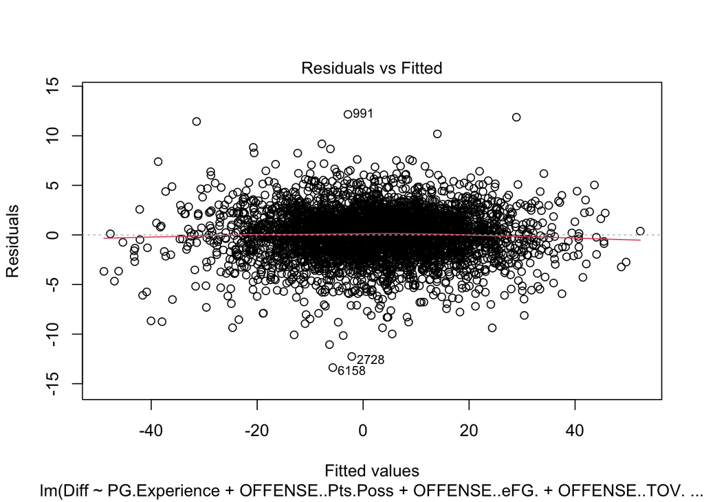

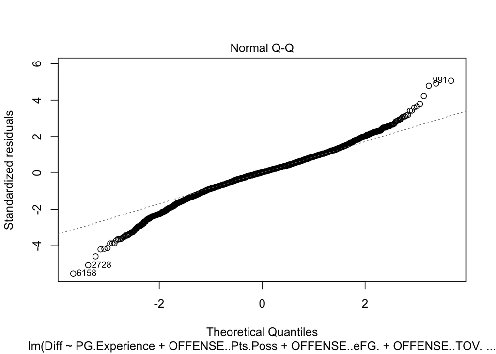

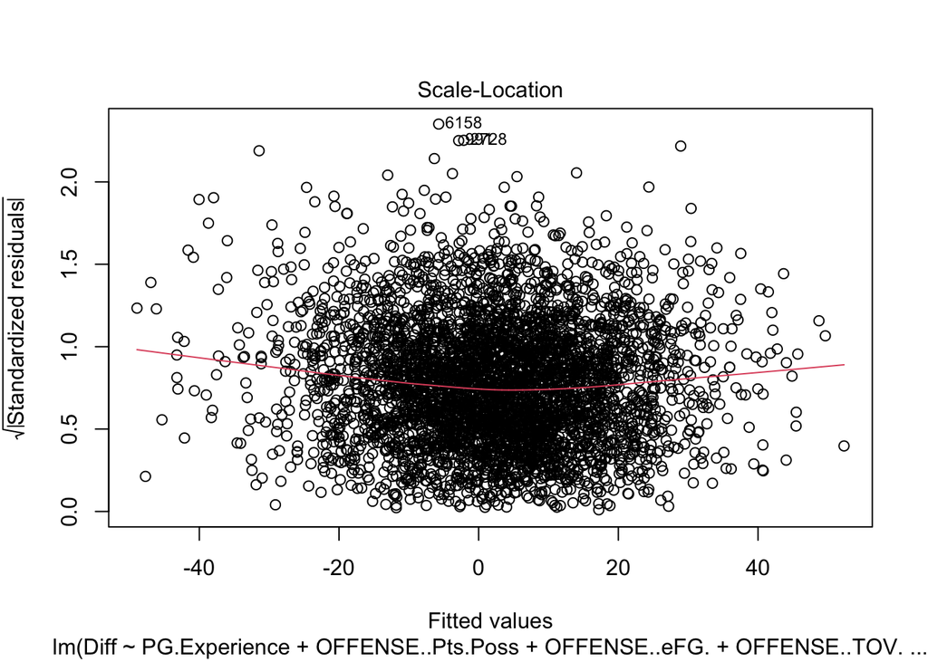

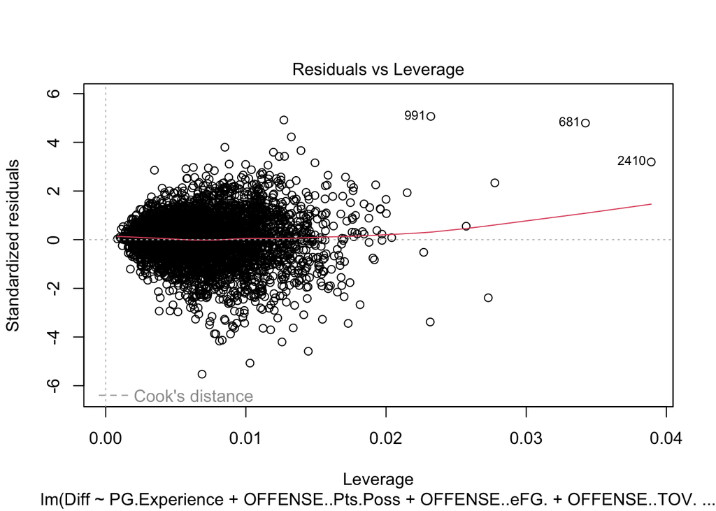

```
## Analysis of Variance Table
##
## Response: Diff
##                                   Df Sum Sq Mean Sq    F value    Pr(>F)
## PG.Experience                      1  12957   12957  2196.3024 < 2.2e-16 ***
## OFFENSE..Pts.Poss                  1 380172  380172 64442.2945 < 2.2e-16 ***
## OFFENSE..eFG.                      1      2       2     0.2787 0.5975815
## OFFENSE..TOV.                      1   1634    1634   276.9531 < 2.2e-16 ***
## OFFENSE..ORB.                      1    695     695   117.7292 < 2.2e-16 ***
## OFFENSE..FT.Rate                   1      3       3     0.4802 0.4883644
## DEFENSE..eFG.                      1 276149  276149 46809.5664 < 2.2e-16 ***
## DEFENSE..TOV.                      1  42396   42396  7186.4883 < 2.2e-16 ***
## DEFENSE..ORB.                      1  48212   48212  8172.3363 < 2.2e-16 ***
## DEFENSE..FT.Rate                   1  15760   15760  2671.4821 < 2.2e-16 ***
## OFFENSE..Rim.Frequency             1      9       9     1.5089 0.2193704
## OFFENSE..All.Three.Frequency       1      4       4     0.7515 0.3860445
## OFFENSE..Short.Mid.FG.             1     52      52     8.8528 0.0029434 **
## OFFENSE..Corner.Three.FG.          1     58      58     9.7660 0.0017901 **
## HALFCOURT..Pts.Play                1     22      22     3.6827 0.0550492 .
## HALFCOURT..OREB.                   1      4       4     0.7112 0.3990935
## HALFCOURT....of.Plays              1      1       1     0.1768 0.6741734
## PUTBACKS..Plays.Miss               1     86      86    14.5649 0.0001374 ***
## DEFENSE..Corner.Three.Frequency    1    191     191    32.3622 1.368e-08 ***
## DEFENSE..All.Three.Frequency       1    124     124    20.9707 4.801e-06 ***
## DEFENSE..Rim.FG.                   1     39      39     6.6067 0.0101947 *
## DEFENSE..Short.Mid.FG.             1     24      24     4.0508 0.0442166 *
## DEFENSE..Long.Mid.FG.              1     19      19     3.2466 0.0716443 .
## DEFENSE..Corner.Three.FG.          1     42      42     7.1707 0.0074400 **
## DEFENSE.HALFCOURT..Pts.Play        1    506     506    85.6949 < 2.2e-16 ***
## DEFENSE.HALFCOURT....of.Plays      1     65      65    10.9633 0.0009374 ***
## DEFENSE.PUTBACKS..Plays.Miss       1    102     102    17.3742 3.133e-05 ***
## DEFENSE.PUTBACKS..Pts.Play         1    477     477    80.8314 < 2.2e-16 ***
## Residuals                       4118  24294       6
## ---
## Signif. codes:  0 '***' 0.001 '**' 0.01 '*' 0.05 '.' 0.1 ' ' 1
```

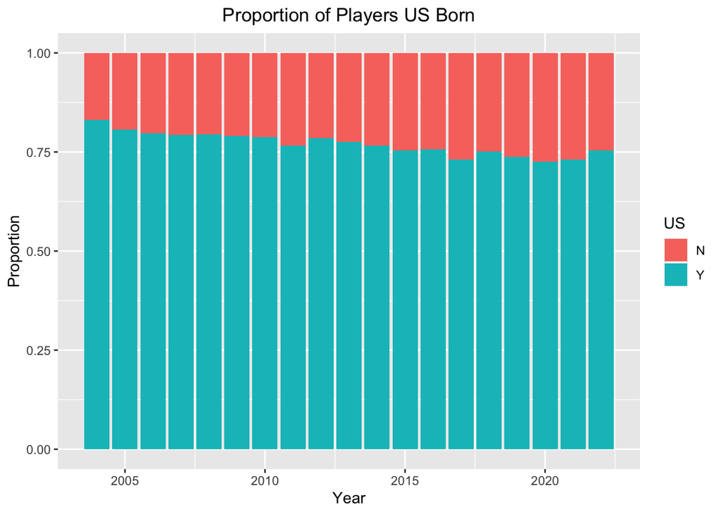

Here we can the proportion of players of each year who have an exclusive nationality of “United States”, represented by the blue. It has a discernible trend of decreasing as time has passed, from the mid-80s to around 75% today. However, this only give us proportional data, not the underlying origins of the foreign players contributing to this trend. To analyze this an interact-able table has been produced to allow for searching of individual countries or frequencies.

| Nationality | freq |
| --- | --- |
| Angola | 1 |
| Argentina | 12 |
| ArgentinaItaly | 1 |
| Australia | 18 |
| AustraliaSouth Sudan | 1 |
| Austria | 1 |
| Bahamas | 3 |
| BelgiumFrance | 1 |
| Bosnia and Herzegovina | 3 |
| Bosnia and HerzegovinaCroatia | 3 |

[output cut: 146 more lines]

This table gives us a number for the quantity of unique players from foreign countries, by country, over the past two decades. One can see that Canada and France are well ahead of the next closest countries with 34 and 32 players making it to the NBA respectively. Next closest are all in the teens, where one can see the row for “United StatesNigeria,” which is a distinct form of nationality in our data. This occurs when a player is born in one country but has a legal nationality of another. This particular case represents the number of players born in the United States but to Nigerian parents. Certain countries like Nigeria, Germany, and Greece have citizenship established under the principal of jus sanguinis, i.e. by birth to parents with that nationality. It can still be granted to persons with an affiliation to the country, or to a permanent resident who has lived in the country for a given period of time through naturalization. The distinct row here shows how prevalent US born players of Nigerian descent are in the NBA today.

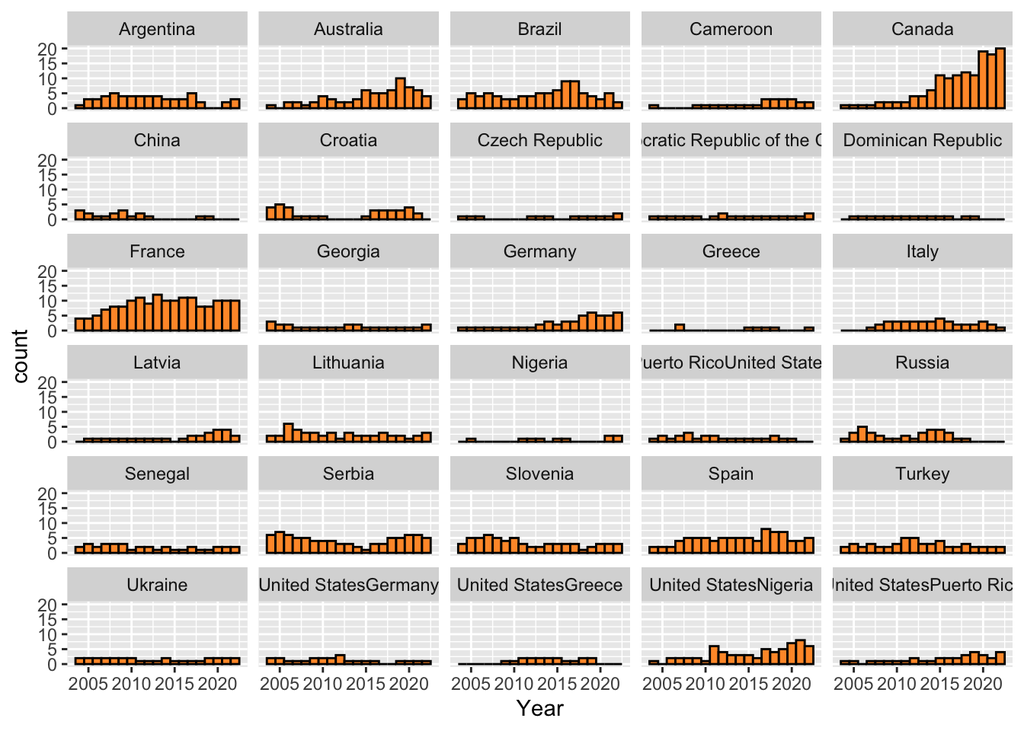

From this we can get a relative idea of what the international player distribution have been like over the past ~20 years. This figure lets the eye gravitate to the biggest distributions with the biggest changes, while passing over the smaller ones with little change. We can see that France and Canada in particular stand out, as expected given that they have by far the largest number of players in the league out of any foreign countries. Additionally, countries like Australia and Germany also catch the eye as they display an increasing trend as well. Yet once more attention is paid to searching the many histograms displayed smaller things stand out that prompt further questions. Chinese players were never a large group, but have become virtually nonexistent in the past decade. One must also notice that certain countries seem to have bi-modal distributions that raise unique questions of their own.

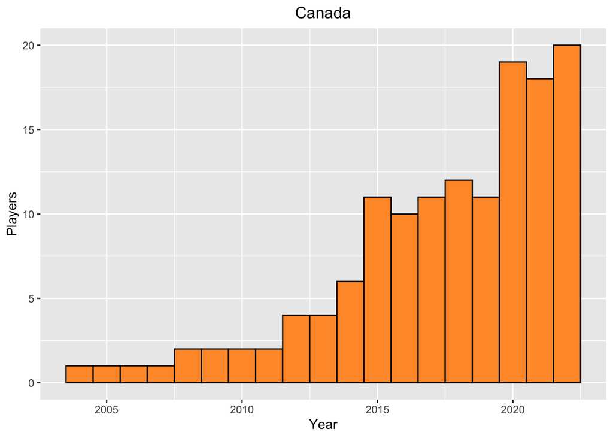

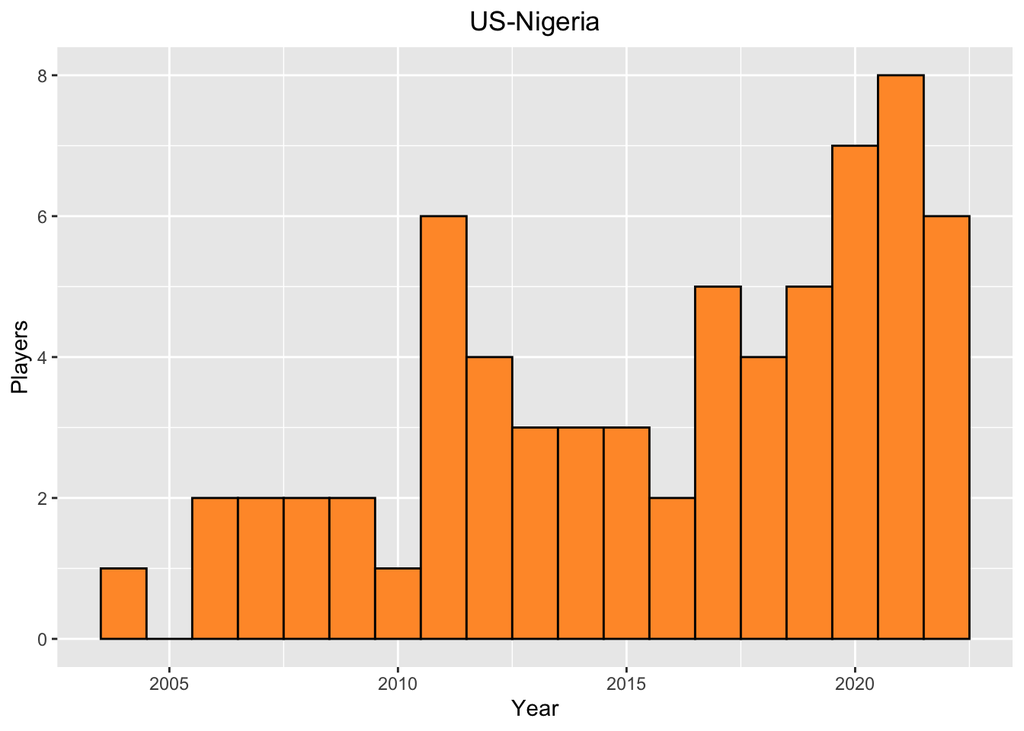

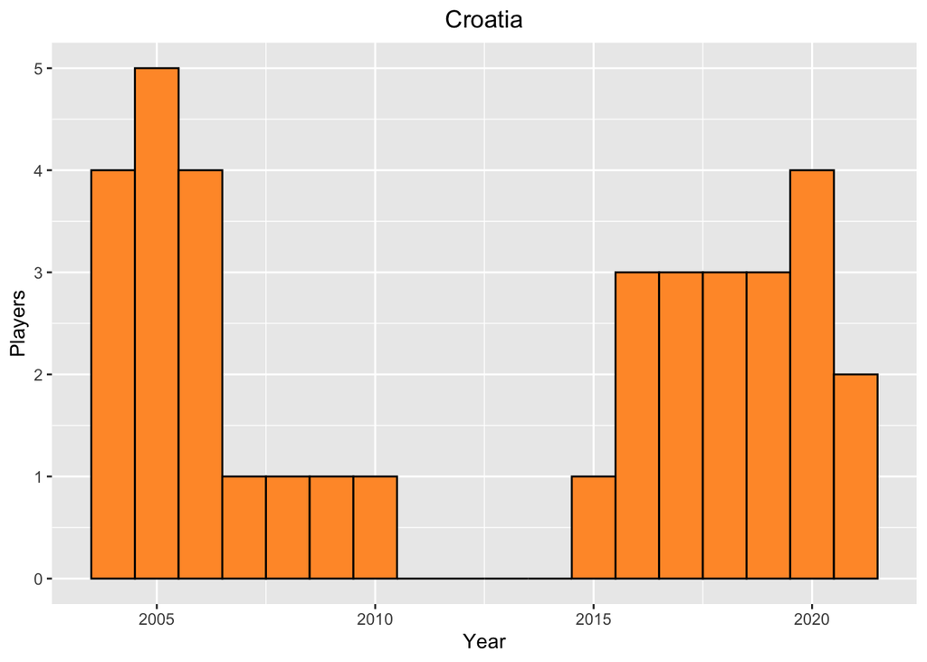

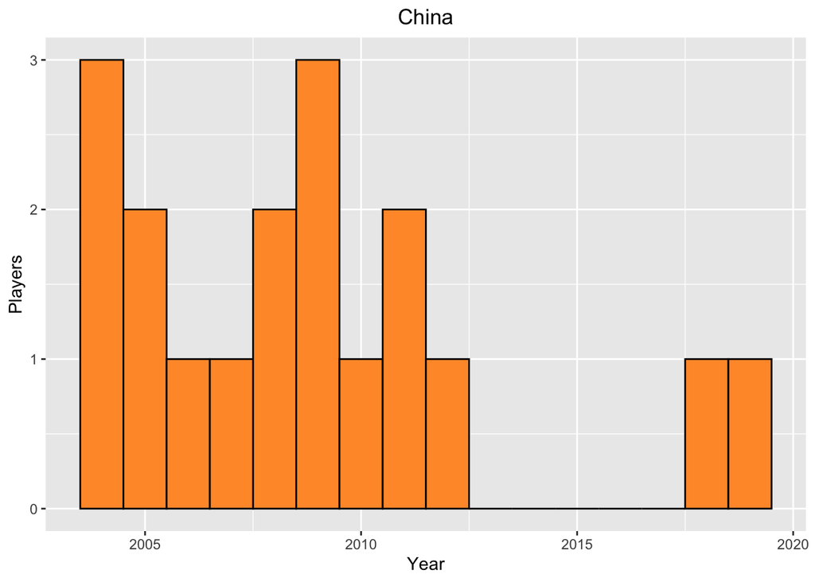

In these paired down examples one can more clearly see these trends. Such as with Canada, where growth starts to take off a few years after 2010. This could be due to a generation of kids growing up with watching the Toronto Raptors who had their inaugural season in 1995. That coupled with the establishment of big basketball stars in Canada and the growth of youth basketball could have combined to create this trend right around the 18th birthday of the Toronto Raptors franchise. Moving to China, a decreasing trend is present with just one Chinese player appearing in the NBA since 2012. This could be due to the rise of the Chinese Basketball association and the push to keep talent at home in an effort to boost viewership to eventually compete with the NBA. Another interesting distribution is that of Croatia, which appears bi-modal in shape. With a trough forming from the late 2000s until after 2015. This happens to roughly correspond to one generation, or about 18 years, after the upheaval of the fall of communism and the subsequent war of independence within Croatia.

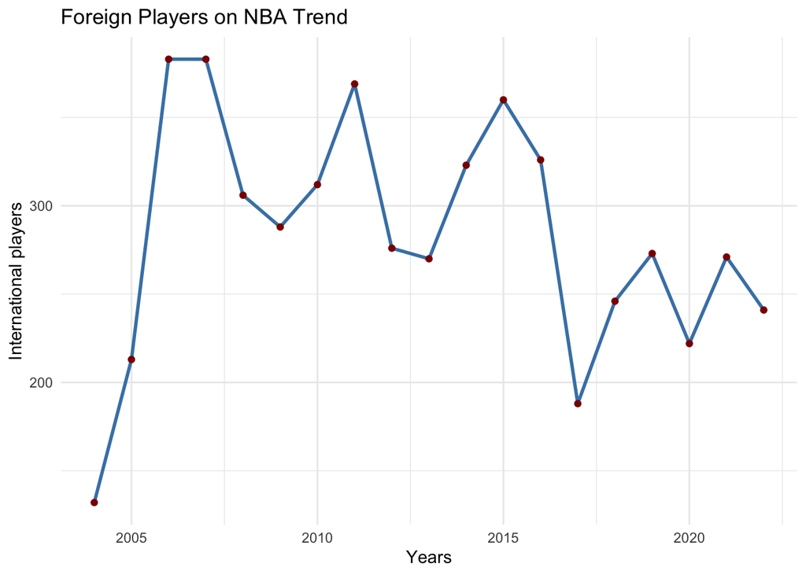

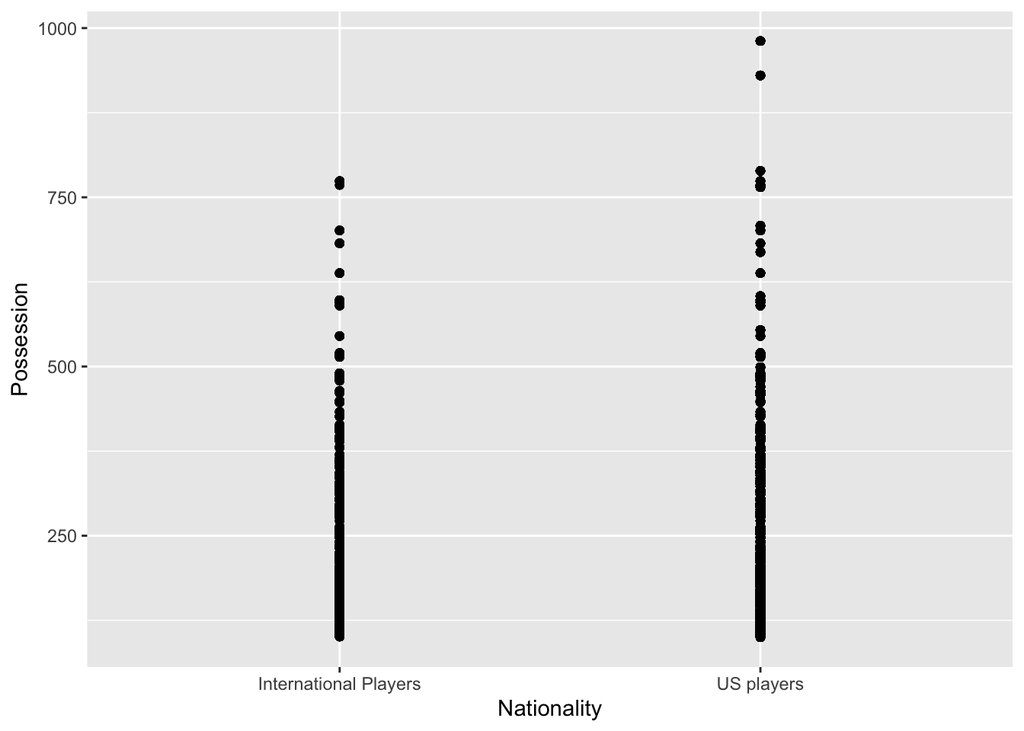

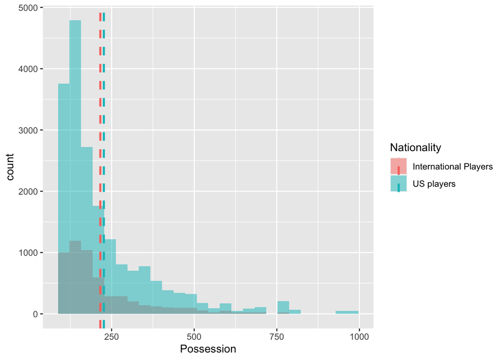

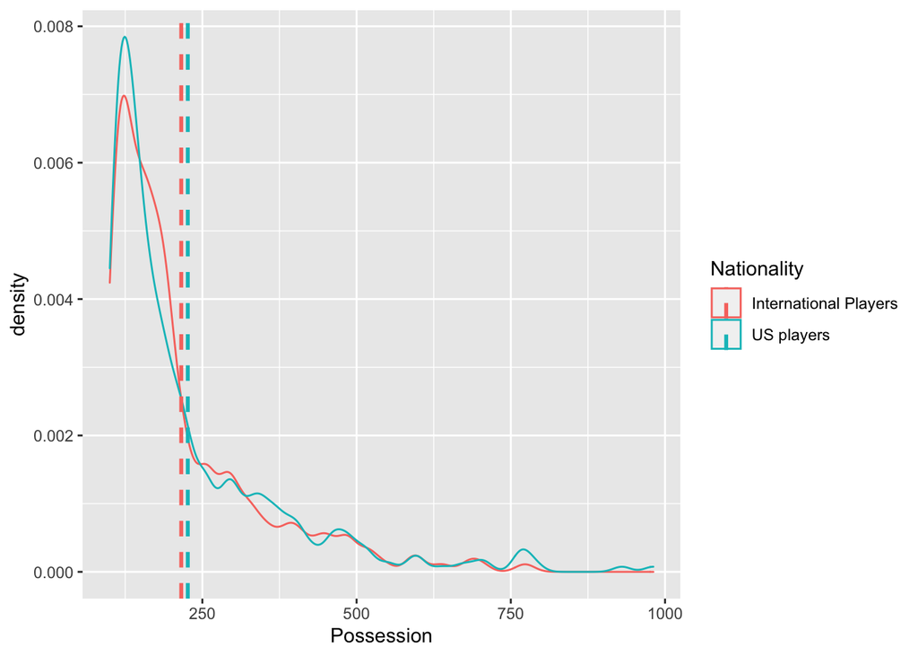

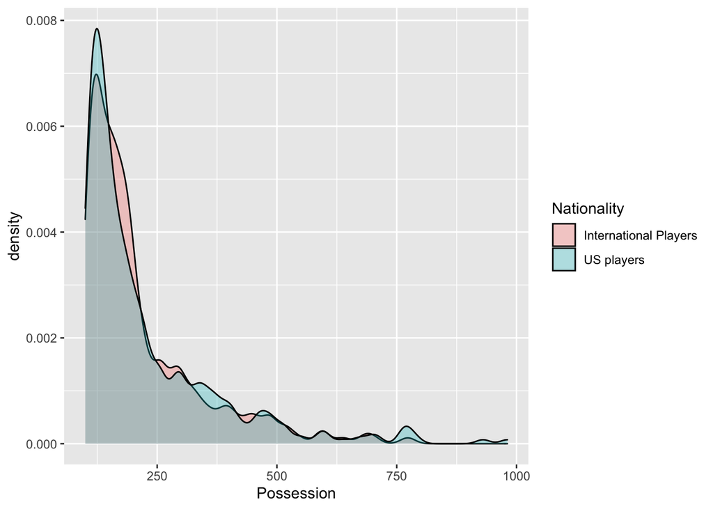

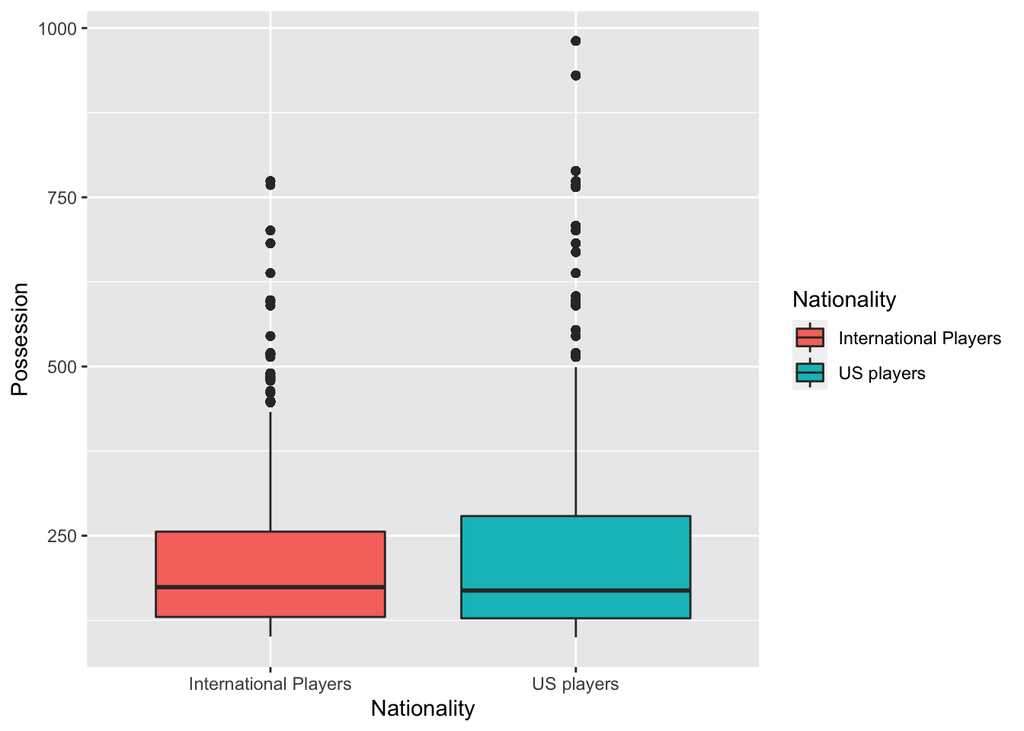

Next, it was investigated if the most used lineups included international players. It was decided that possession would be a great indicator of it. Thus,the dataset was arranged by decreasing possession and then histograms, density plots, and boxplots were created. Even from the geom_point graph, it can be deduced that in teams with the highest possession, US players are utilized more than international players. Furthermore, density plots and histograms indicate that international players are utilized more in teams with lower possession than in teams with higher possession. However, it can be sees from the boxplot that the mean of possession of national players and international players are close to each other. US players’ boxplot was right-skewed meaning they had more players close to higher possessions.

# CONCLUSION